# Business Analytics Club Tidyverse Introduction

Matthew Buddensick

9/16/2020

## Introduction

R Markdown file introducing the tidyverse for the SUNY New Paltz Business Analytics Club. This is just an introduction to some of the packages included in the tidyverse, for more in depth details and extra packages that compliment the tidyverse go [here](https://www.tidyverse.org/packages/).

## The Data

The data we will be using for a majority of this notebook is the **diamonds** data set which can be found on [kaggle](https://www.kaggle.com/shivam2503/diamonds).

```r
diamonds <- read_csv("diamonds.csv")
```

Here we used the **read_csv** function from the readr package in the tidyverse, which is faster than base R’s **read.csv** function, and also gives more information, such as how the variables were imported.

```r
diamonds %>%
    glimpse()
```

```
## Rows: 53,940
## Columns: 11
## $ X1      <dbl> 1, 2, 3, 4, 5, 6, 7, 8, 9, 10, 11, 12, 13, 14, 15, 16, 17, ...
## $ carat   <dbl> 0.23, 0.21, 0.23, 0.29, 0.31, 0.24, 0.24, 0.26, 0.22, 0.23,...
## $ cut     <chr> "Ideal", "Premium", "Good", "Premium", "Good", "Very Good",...
## $ color   <chr> "E", "E", "E", "I", "J", "J", "I", "H", "E", "H", "J", "J",...
## $ clarity <chr> "SI2", "SI1", "VS1", "VS2", "SI2", "VVS2", "VVS1", "SI1", "...
## $ depth   <dbl> 61.5, 59.8, 56.9, 62.4, 63.3, 62.8, 62.3, 61.9, 65.1, 59.4,...
## $ table   <dbl> 55, 61, 65, 58, 58, 57, 57, 55, 61, 61, 55, 56, 61, 54, 62,...
## $ price   <dbl> 326, 326, 327, 334, 335, 336, 336, 337, 337, 338, 339, 340,...
## $ x       <dbl> 3.95, 3.89, 4.05, 4.20, 4.34, 3.94, 3.95, 4.07, 3.87, 4.00,...
## $ y       <dbl> 3.98, 3.84, 4.07, 4.23, 4.35, 3.96, 3.98, 4.11, 3.78, 4.05,...
## $ z       <dbl> 2.43, 2.31, 2.31, 2.63, 2.75, 2.48, 2.47, 2.53, 2.49, 2.39,...
```

The **glimpse** function is very similar to base R’s **str** function. We can see that there are 53940 rows in the data set and 11 columns. If we want to see just the number of rows and columns without any of the data we could use the **dim** function, which takes a single object as an input. The **%>%** symbol is called the *pipe operator*. This takes the output of one statement and passes it onto the next statement. In this chunk of code you can read it as “I have the diamonds data, then I use the glimpse function to look at it.”

## Dplyr

Dplyr is one of the most important packages included in the tidyverse. It provides functions, or verbs, that allow you to easily manipulate data. In this section we will go over the select, filter, arrange, mutate and summarize verbs. To download a cheat sheet for common dplyr functions click [here](https://github.com/rstudio/cheatsheets/raw/master/data-transformation.pdf).

### Select

The **select** verb allows you to select only certain columns from the data set. It is not very useful with the data we are using ((there are only 11, but can be very useful when working with data with 100s of columns.

```r
# Select just price, caret, cut, color and clarity
diamonds %>%
    select(price, carat, cut, color, clarity)
```

```
## # A tibble: 53,940 x 5
##    price carat cut       color clarity
##    <dbl> <dbl> <chr>     <chr> <chr>
##  1   326 0.23  Ideal     E     SI2
##  2   326 0.21  Premium   E     SI1
##  3   327 0.23  Good      E     VS1
##  4   334 0.290 Premium   I     VS2
##  5   335 0.31  Good      J     SI2
##  6   336 0.24  Very Good J     VVS2
##  7   336 0.24  Very Good I     VVS1
##  8   337 0.26  Very Good H     SI1
##  9   337 0.22  Fair      E     VS2
## 10   338 0.23  Very Good H     VS1
## # ... with 53,930 more rows
```

```r
# Select that start with c
diamonds %>%
    select(starts_with("c"))
```

```
## # A tibble: 53,940 x 4
##    carat cut       color clarity
##    <dbl> <chr>     <chr> <chr>
##  1 0.23  Ideal     E     SI2
##  2 0.21  Premium   E     SI1
##  3 0.23  Good      E     VS1
##  4 0.290 Premium   I     VS2
##  5 0.31  Good      J     SI2
##  6 0.24  Very Good J     VVS2
##  7 0.24  Very Good I     VVS1
##  8 0.26  Very Good H     SI1
##  9 0.22  Fair      E     VS2
## 10 0.23  Very Good H     VS1
## # ... with 53,930 more rows
```

```r
# Select columns that end with e
diamonds %>%
    select(ends_with("e"))
```

```
## # A tibble: 53,940 x 2
##    table price
##    <dbl> <dbl>
##  1    55   326
##  2    61   326
##  3    65   327
##  4    58   334
##  5    58   335
##  6    57   336
##  7    57   336
##  8    55   337
##  9    61   337
## 10    61   338
## # ... with 53,930 more rows
```

```r
# Select columns that contain ar
diamonds %>%
    select(contains("ar"))
```

```
## # A tibble: 53,940 x 2
##    carat clarity
##    <dbl> <chr>
##  1 0.23  SI2
##  2 0.21  SI1
##  3 0.23  VS1
##  4 0.290 VS2
##  5 0.31  SI2
##  6 0.24  VVS2
##  7 0.24  VVS1
##  8 0.26  SI1
##  9 0.22  VS2
## 10 0.23  VS1
## # ... with 53,930 more rows
```

```r
# Select columns from carat to price
diamonds %>%
    select(carat:price)
```

```
## # A tibble: 53,940 x 7
##    carat cut       color clarity depth table price
##    <dbl> <chr>     <chr> <chr>   <dbl> <dbl> <dbl>
##  1 0.23  Ideal     E     SI2      61.5    55   326
##  2 0.21  Premium   E     SI1      59.8    61   326
##  3 0.23  Good      E     VS1      56.9    65   327
##  4 0.290 Premium   I     VS2      62.4    58   334
##  5 0.31  Good      J     SI2      63.3    58   335
##  6 0.24  Very Good J     VVS2     62.8    57   336
##  7 0.24  Very Good I     VVS1     62.3    57   336
##  8 0.26  Very Good H     SI1      61.9    55   337
##  9 0.22  Fair      E     VS2      65.1    61   337
## 10 0.23  Very Good H     VS1      59.4    61   338
## # ... with 53,930 more rows
```

```r
# Remove the X1 column from the dataset, it is just an idex and is not needed, save as diamonds
(diamonds <- diamonds %>%
    select(-X1))
```

```
## # A tibble: 53,940 x 10
##    carat cut       color clarity depth table price     x     y     z
##    <dbl> <chr>     <chr> <chr>   <dbl> <dbl> <dbl> <dbl> <dbl> <dbl>
##  1 0.23  Ideal     E     SI2      61.5    55   326  3.95  3.98  2.43
##  2 0.21  Premium   E     SI1      59.8    61   326  3.89  3.84  2.31
##  3 0.23  Good      E     VS1      56.9    65   327  4.05  4.07  2.31
##  4 0.290 Premium   I     VS2      62.4    58   334  4.2   4.23  2.63
##  5 0.31  Good      J     SI2      63.3    58   335  4.34  4.35  2.75
##  6 0.24  Very Good J     VVS2     62.8    57   336  3.94  3.96  2.48
##  7 0.24  Very Good I     VVS1     62.3    57   336  3.95  3.98  2.47
##  8 0.26  Very Good H     SI1      61.9    55   337  4.07  4.11  2.53
##  9 0.22  Fair      E     VS2      65.1    61   337  3.87  3.78  2.49
## 10 0.23  Very Good H     VS1      59.4    61   338  4     4.05  2.39
## # ... with 53,930 more rows
```

### Filter

The **filter** verb allows you to subset observations.

```r
# Filter for price over $500
diamonds %>%
    filter(price > 500)
```

```
## # A tibble: 52,191 x 10
##    carat cut       color clarity depth table price     x     y     z
##    <dbl> <chr>     <chr> <chr>   <dbl> <dbl> <dbl> <dbl> <dbl> <dbl>
##  1  0.35 Ideal     I     VS1      60.9  57     552  4.54  4.59  2.78
##  2  0.3  Premium   D     SI1      62.6  59     552  4.23  4.27  2.66
##  3  0.3  Ideal     D     SI1      62.5  57     552  4.29  4.32  2.69
##  4  0.3  Ideal     D     SI1      62.1  56     552  4.3   4.33  2.68
##  5  0.42 Premium   I     SI2      61.5  59     552  4.78  4.84  2.96
##  6  0.28 Ideal     G     VVS2     61.4  56     553  4.19  4.22  2.58
##  7  0.32 Ideal     I     VVS1     62    55.3   553  4.39  4.42  2.73
##  8  0.31 Very Good G     SI1      63.3  57     553  4.33  4.3   2.73
##  9  0.31 Premium   G     SI1      61.8  58     553  4.35  4.32  2.68
## 10  0.24 Premium   E     VVS1     60.7  58     553  4.01  4.03  2.44
## # ... with 52,181 more rows
```

```r
# Filter for only Good and Very Good cut diamonds
diamonds %>%
    filter(cut == c("Good", "Very Good"))
```

```
## # A tibble: 8,449 x 10
##    carat cut       color clarity depth table price     x     y     z
##    <dbl> <chr>     <chr> <chr>   <dbl> <dbl> <dbl> <dbl> <dbl> <dbl>
##  1  0.23 Good      E     VS1      56.9    65   327  4.05  4.07  2.31
##  2  0.31 Good      J     SI2      63.3    58   335  4.34  4.35  2.75
##  3  0.24 Very Good J     VVS2     62.8    57   336  3.94  3.96  2.48
##  4  0.26 Very Good H     SI1      61.9    55   337  4.07  4.11  2.53
##  5  0.23 Very Good H     VS1      59.4    61   338  4     4.05  2.39
##  6  0.3  Good      J     SI1      64      55   339  4.25  4.28  2.73
##  7  0.3  Good      J     SI1      63.8    56   351  4.23  4.26  2.71
##  8  0.3  Very Good J     SI1      62.7    59   351  4.21  4.27  2.66
##  9  0.3  Good      I     SI2      63.3    56   351  4.26  4.3   2.71
## 10  0.23 Very Good E     VS2      63.8    55   352  3.85  3.92  2.48
## # ... with 8,439 more rows
```

### Arrange

The **Arrange** verb allows you to change the order of rows in the data set.

```r
# Arrange the data so that it is descending by price
diamonds %>%
    arrange(desc(price))
```

```
## # A tibble: 53,940 x 10
##    carat cut       color clarity depth table price     x     y     z
##    <dbl> <chr>     <chr> <chr>   <dbl> <dbl> <dbl> <dbl> <dbl> <dbl>
##  1  2.29 Premium   I     VS2      60.8    60 18823  8.5   8.47  5.16
##  2  2    Very Good G     SI1      63.5    56 18818  7.9   7.97  5.04
##  3  1.51 Ideal     G     IF       61.7    55 18806  7.37  7.41  4.56
##  4  2.07 Ideal     G     SI2      62.5    55 18804  8.2   8.13  5.11
##  5  2    Very Good H     SI1      62.8    57 18803  7.95  8     5.01
##  6  2.29 Premium   I     SI1      61.8    59 18797  8.52  8.45  5.24
##  7  2.04 Premium   H     SI1      58.1    60 18795  8.37  8.28  4.84
##  8  2    Premium   I     VS1      60.8    59 18795  8.13  8.02  4.91
##  9  1.71 Premium   F     VS2      62.3    59 18791  7.57  7.53  4.7
## 10  2.15 Ideal     G     SI2      62.6    54 18791  8.29  8.35  5.21
## # ... with 53,930 more rows
```

```r
# Arrange the data so that is in increasing by price
diamonds %>%
    arrange(price)
```

```
## # A tibble: 53,940 x 10
##    carat cut       color clarity depth table price     x     y     z
##    <dbl> <chr>     <chr> <chr>   <dbl> <dbl> <dbl> <dbl> <dbl> <dbl>
##  1 0.23  Ideal     E     SI2      61.5    55   326  3.95  3.98  2.43
##  2 0.21  Premium   E     SI1      59.8    61   326  3.89  3.84  2.31
##  3 0.23  Good      E     VS1      56.9    65   327  4.05  4.07  2.31
##  4 0.290 Premium   I     VS2      62.4    58   334  4.2   4.23  2.63
##  5 0.31  Good      J     SI2      63.3    58   335  4.34  4.35  2.75
##  6 0.24  Very Good J     VVS2     62.8    57   336  3.94  3.96  2.48
##  7 0.24  Very Good I     VVS1     62.3    57   336  3.95  3.98  2.47
##  8 0.26  Very Good H     SI1      61.9    55   337  4.07  4.11  2.53
##  9 0.22  Fair      E     VS2      65.1    61   337  3.87  3.78  2.49
## 10 0.23  Very Good H     VS1      59.4    61   338  4     4.05  2.39
## # ... with 53,930 more rows
```

### Mutate

The **mutate** verb allows you to add new columns to your data set, or overwrite existing columns.

```r
# First use the select verb to drop the depth column and save as diamonds_mutate
(diamonds_mutate <- diamonds %>%
     select(-depth))
```

```
## # A tibble: 53,940 x 9
##    carat cut       color clarity table price     x     y     z
##    <dbl> <chr>     <chr> <chr>   <dbl> <dbl> <dbl> <dbl> <dbl>
##  1 0.23  Ideal     E     SI2        55   326  3.95  3.98  2.43
##  2 0.21  Premium   E     SI1        61   326  3.89  3.84  2.31
##  3 0.23  Good      E     VS1        65   327  4.05  4.07  2.31
##  4 0.290 Premium   I     VS2        58   334  4.2   4.23  2.63
##  5 0.31  Good      J     SI2        58   335  4.34  4.35  2.75
##  6 0.24  Very Good J     VVS2       57   336  3.94  3.96  2.48
##  7 0.24  Very Good I     VVS1       57   336  3.95  3.98  2.47
##  8 0.26  Very Good H     SI1        55   337  4.07  4.11  2.53
##  9 0.22  Fair      E     VS2        61   337  3.87  3.78  2.49
## 10 0.23  Very Good H     VS1        61   338  4     4.05  2.39
## # ... with 53,930 more rows
```

```r
# Readd the depth column, it is calculated as z / mean(x, y), save as diamonds_original
(diamonds_original <- diamonds_mutate %>%
     mutate(depth = z / (mean(x) + mean(y))))
```

```
## # A tibble: 53,940 x 10
##    carat cut       color clarity table price     x     y     z depth
##    <dbl> <chr>     <chr> <chr>   <dbl> <dbl> <dbl> <dbl> <dbl> <dbl>
##  1 0.23  Ideal     E     SI2        55   326  3.95  3.98  2.43 0.212
##  2 0.21  Premium   E     SI1        61   326  3.89  3.84  2.31 0.201
##  3 0.23  Good      E     VS1        65   327  4.05  4.07  2.31 0.201
##  4 0.290 Premium   I     VS2        58   334  4.2   4.23  2.63 0.229
##  5 0.31  Good      J     SI2        58   335  4.34  4.35  2.75 0.240
##  6 0.24  Very Good J     VVS2       57   336  3.94  3.96  2.48 0.216
##  7 0.24  Very Good I     VVS1       57   336  3.95  3.98  2.47 0.215
##  8 0.26  Very Good H     SI1        55   337  4.07  4.11  2.53 0.221
##  9 0.22  Fair      E     VS2        61   337  3.87  3.78  2.49 0.217
## 10 0.23  Very Good H     VS1        61   338  4     4.05  2.39 0.208
## # ... with 53,930 more rows
```

```r
# If the column is a character column, change it to a factor, save as diamonds_factor
diamonds %>%
    mutate_if(is.character, factor)
```

```
## # A tibble: 53,940 x 10
##    carat cut       color clarity depth table price     x     y     z
##    <dbl> <fct>     <fct> <fct>   <dbl> <dbl> <dbl> <dbl> <dbl> <dbl>
##  1 0.23  Ideal     E     SI2      61.5    55   326  3.95  3.98  2.43
##  2 0.21  Premium   E     SI1      59.8    61   326  3.89  3.84  2.31
##  3 0.23  Good      E     VS1      56.9    65   327  4.05  4.07  2.31
##  4 0.290 Premium   I     VS2      62.4    58   334  4.2   4.23  2.63
##  5 0.31  Good      J     SI2      63.3    58   335  4.34  4.35  2.75
##  6 0.24  Very Good J     VVS2     62.8    57   336  3.94  3.96  2.48
##  7 0.24  Very Good I     VVS1     62.3    57   336  3.95  3.98  2.47
##  8 0.26  Very Good H     SI1      61.9    55   337  4.07  4.11  2.53
##  9 0.22  Fair      E     VS2      65.1    61   337  3.87  3.78  2.49
## 10 0.23  Very Good H     VS1      59.4    61   338  4     4.05  2.39
## # ... with 53,930 more rows
```

```r
# Use the head command on the cut column
head(diamonds$cut)
```

```
## [1] "Ideal"     "Premium"   "Good"      "Premium"   "Good"      "Very Good"
```

```r
# Make a new column (price_factor) that is a factor, and is equal to 1 if the price of a diamonds is greater than the median price, and 0 if it is lower, save the result to diamonds
(diamonds <- diamonds %>%
     mutate(price_factor = factor(ifelse(price > median(price), 1, 0))))
```

```
## # A tibble: 53,940 x 11
##    carat cut      color clarity depth table price     x     y     z price_factor
##    <dbl> <chr>    <chr> <chr>   <dbl> <dbl> <dbl> <dbl> <dbl> <dbl> <fct>
##  1 0.23  Ideal    E     SI2      61.5    55   326  3.95  3.98  2.43 0
##  2 0.21  Premium  E     SI1      59.8    61   326  3.89  3.84  2.31 0
##  3 0.23  Good     E     VS1      56.9    65   327  4.05  4.07  2.31 0
##  4 0.290 Premium  I     VS2      62.4    58   334  4.2   4.23  2.63 0
##  5 0.31  Good     J     SI2      63.3    58   335  4.34  4.35  2.75 0
##  6 0.24  Very Go~ J     VVS2     62.8    57   336  3.94  3.96  2.48 0
##  7 0.24  Very Go~ I     VVS1     62.3    57   336  3.95  3.98  2.47 0
##  8 0.26  Very Go~ H     SI1      61.9    55   337  4.07  4.11  2.53 0
##  9 0.22  Fair     E     VS2      65.1    61   337  3.87  3.78  2.49 0
## 10 0.23  Very Go~ H     VS1      59.4    61   338  4     4.05  2.39 0
## # ... with 53,930 more rows
```

```r
# Use the table function on the price_factor column
table(diamonds$price_factor)
```

```
##
##     0     1
## 26985 26955
```

### Summarize

The **summarize** verb allows you to get summary statistics based off of your data. Is it commonly used with the **group_by** function, which is also apart of dplyr.

```r
# Generate mean of price
diamonds %>%
    summarize(mean(price))
```

```
## # A tibble: 1 x 1
##   `mean(price)`
##           <dbl>
## 1         3933.
```

```r
# Generate mean of price by cut
diamonds %>%
    group_by(cut) %>%
    summarize(mean(price))
```

```
## # A tibble: 5 x 2
##   cut       `mean(price)`
##   <chr>             <dbl>
## 1 Fair              4359.
## 2 Good              3929.
## 3 Ideal             3458.
## 4 Premium           4584.
## 5 Very Good         3982.
```

```r
# Generate mean of price for each cut and clarity
diamonds %>%
    group_by(cut, clarity) %>%
    summarize(mean(price))
```

```
## # A tibble: 40 x 3
## # Groups:   cut [5]
##    cut   clarity `mean(price)`
##    <chr> <chr>           <dbl>
##  1 Fair  I1              3704.
##  2 Fair  IF              1912.
##  3 Fair  SI1             4208.
##  4 Fair  SI2             5174.
##  5 Fair  VS1             4165.
##  6 Fair  VS2             4175.
##  7 Fair  VVS1            3871.
##  8 Fair  VVS2            3350.
##  9 Good  I1              3597.
## 10 Good  IF              4098.
## # ... with 30 more rows
```

## Stringr

Stringr is a package in the tidyverse and is built on top of the stringi package. It plays a big role in data cleaning tasks, and makes working with strings easy. To download a cheat sheet on common stringr functions, click [here](https://github.com/rstudio/cheatsheets/raw/master/strings.pdf).

```r
string_vector <- c("Suny", "New Paltz", "analytics", "club")
```

```r
# Make all values of string_vector entirely lowercase
str_to_lower(string_vector)
```

```
## [1] "suny"      "new paltz" "analytics" "club"
```

```r
# Make all values of string_vector entirely uppercase
str_to_upper(string_vector)
```

```
## [1] "SUNY"      "NEW PALTZ" "ANALYTICS" "CLUB"
```

```r
# Split the values in string_vector on a space (notice the output)
str_split(string_vector, pattern = " ")
```

```
## [[1]]
## [1] "Suny"
##
## [[2]]
## [1] "New"   "Paltz"
##
## [[3]]
## [1] "analytics"
##
## [[4]]
## [1] "club"
```

```r
# What is the length of each string in string_vector?
str_length(string_vector)
```

```
## [1] 4 9 9 4
```

```r
# Replace analytics in string_vector with "business analytics"
str_replace(string_vector, pattern = "analytics", replacement = "business analytics")
```

```
## [1] "Suny"               "New Paltz"          "business analytics"
## [4] "club"
```

Stringr also allows us to use regular expressions, which allows you to define and search for a specific pattern. You can find more information on regular expressions in the cheat sheet for stringr above, or by downloading the [regular expression cheatsheet](http://www.rstudio.com/wp-content/uploads/2016/09/RegExCheatsheet.pdf). Here we will do one very simple example of a regular expression without any of the fancy, more complicated syntax.

```r
# Detect strings with a "u" in them
str_detect(string_vector, pattern = "u")
```

```
## [1]  TRUE FALSE FALSE  TRUE
```

## Forecats

Forecats is a package in the tidyverse that helps us deal with categorical variables. Categorical variables have a fixed and known set of possible values, this could be something like sex or education level. This is very useful when doing an analysis, because you will most likely not want to work with characters or strings. You can download a cheat sheet of common forecats functions [here](https://github.com/rstudio/cheatsheets/raw/master/factors.pdf). We will be working with only the cut column of the diamonds data in these examples.

```r
# Convert the cut column into a factor variable and look at the levels, do not save the output
diamonds %>%
    mutate(cut = factor(cut)) %>%
    select(cut) %>%
    pull() %>%
    levels()
```

```
## [1] "Fair"      "Good"      "Ideal"     "Premium"   "Very Good"
```

We want to show the order of the cut variable (Fair -> Ideal) when we create it by making it an ordered factor.

```r
# Create a ordered factor of the cut variable and save it to a vairable called cut_factor
cut_factor <- diamonds %>%
    mutate(cut = factor(cut, levels = c("Fair", "Good", "Very Good", "Premium", "Ideal"), ordered = TRUE)) %>%
    select(cut) %>%
    pull()
```

```r
# Look at the levels of the cut variable using the head() function
head(cut_factor)
```

```
## [1] Ideal     Premium   Good      Premium   Good      Very Good
## Levels: Fair < Good < Very Good < Premium < Ideal
```

```r
# From cut in the original dataset, use fct_lump to create a factor variable with n = 2, save as lumped_cut and print the first couple of rows using head()
lumped_cut <- diamonds %>%
    mutate(cut = fct_lump(cut, n = 2)) %>%
    select(cut) %>%
    pull()
```

```r
# Look at levels using head(
head(lumped_cut)
```

```
## [1] Ideal   Premium Other   Premium Other   Other
## Levels: Ideal Premium Other
```

Note that since cut is an ordered factor, it would not be a good idea to lump them together. You will lose valuable information about the different cuts of diamonds. Use **fct_lump** when you have small groups.

```r
# Recode the levels in cut_factor so that everything is the same except Ideal becomes best, save as cut_recode and use head() to look at it
cut_recode <- cut_factor %>%
    fct_recode("Best" = "Ideal")
```

```r
# Use head on cut_recode
head(cut_recode)
```

```
## [1] Best      Premium   Good      Premium   Good      Very Good
## Levels: Fair < Good < Very Good < Premium < Best
```

## Ggplot2

Ggplot2 allows you to create decorative graphs in R. It is one of the most popular packages for creating data visualizations. You can find a cheat sheet for common ggplot2 graphs and functions [here](https://github.com/rstudio/cheatsheets/blob/master/data-visualization-2.1.pdf). The cheat sheet also provides what types of graphs you can use when working with different variables, which comes in handy in case you forget.

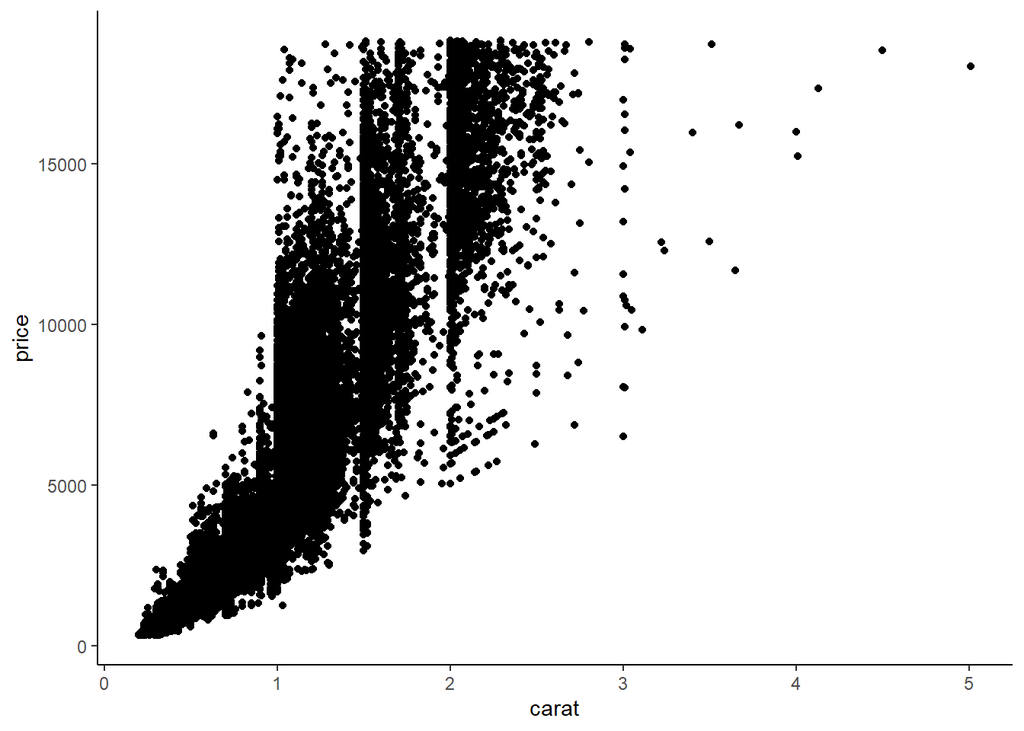

```r
# Create a scatterplot of carat and price
ggplot(diamonds, aes(x = carat, y = price)) +
    geom_point()
```

A lot of the points in the graph seem to be overlapping, we can fix this by using geom_jitter instead of geom_point and also decrease the visibility of each point slightly by decreasing the alpha. We can also change the axis names and add a simple title.

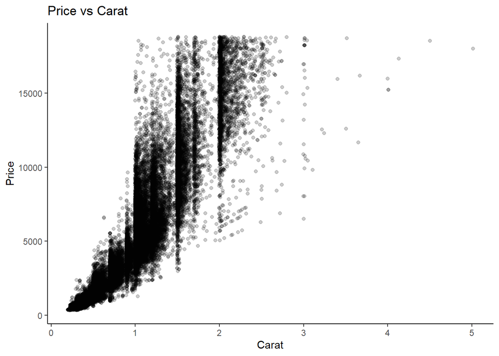

```r
# Use geom_jitter to create a scatterplot and add new axis labels and a title, use alpha = .2
ggplot(diamonds, aes(x = carat, y = price)) +
    geom_jitter(alpha = .2) +
    labs(title = "Price vs Carat", x = "Carat", y = "Price")
```

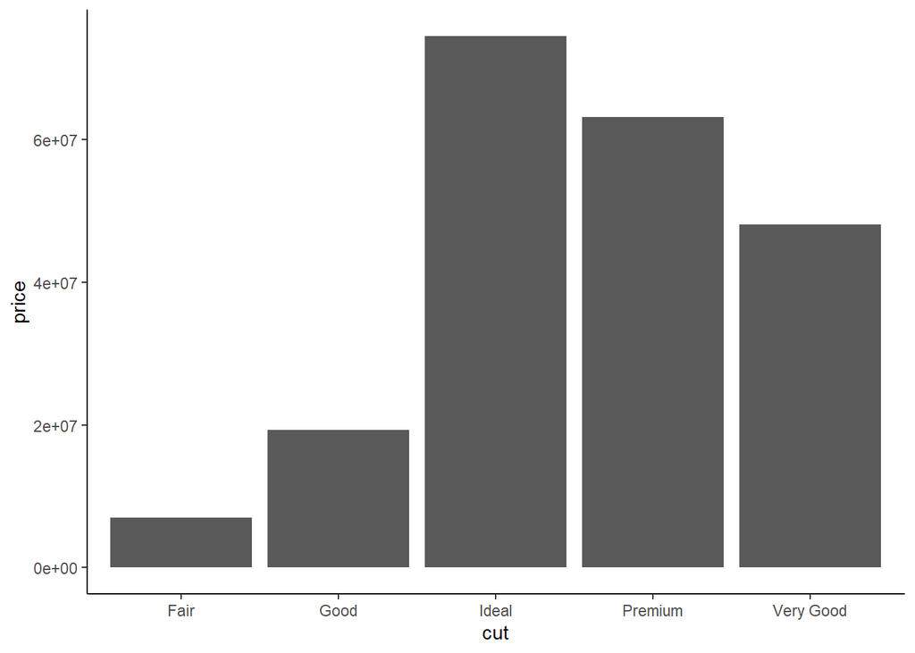

```r
# Create a bar graph of cut and price
ggplot(diamonds, aes(x = cut, y = price)) +
    geom_col()
```

This plot is okay, but with ggplot we can create much nicer looking graphs. Lets flip the coordinates, give the graph some color, change the axis names and give the graph a title.

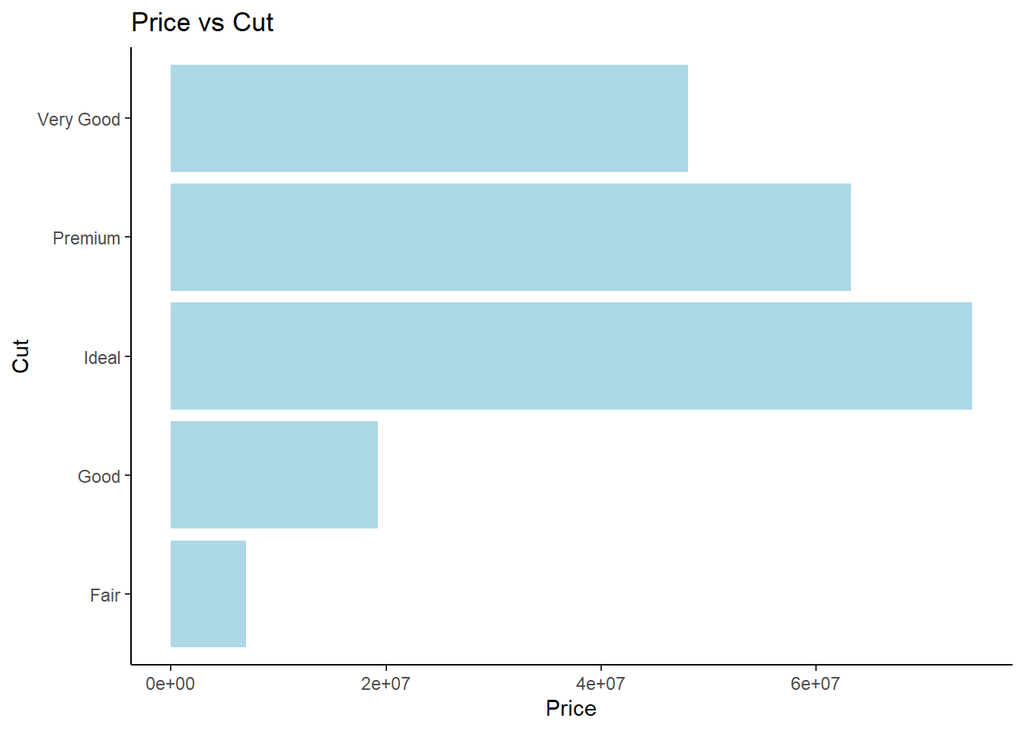

```r
# Create the graph above but add color, new axis names, and a title, flip axis
ggplot(diamonds, aes(x = cut, y = price)) +
    geom_col(fill = "light blue") +
    coord_flip() +
    labs(title = "Price vs Cut", y = "Price", x = "Cut")
```

This graph is good, but lets just say we want the lowest price to be on the top of the graph for some reason. We can do this using forecats **fct_rev** function.

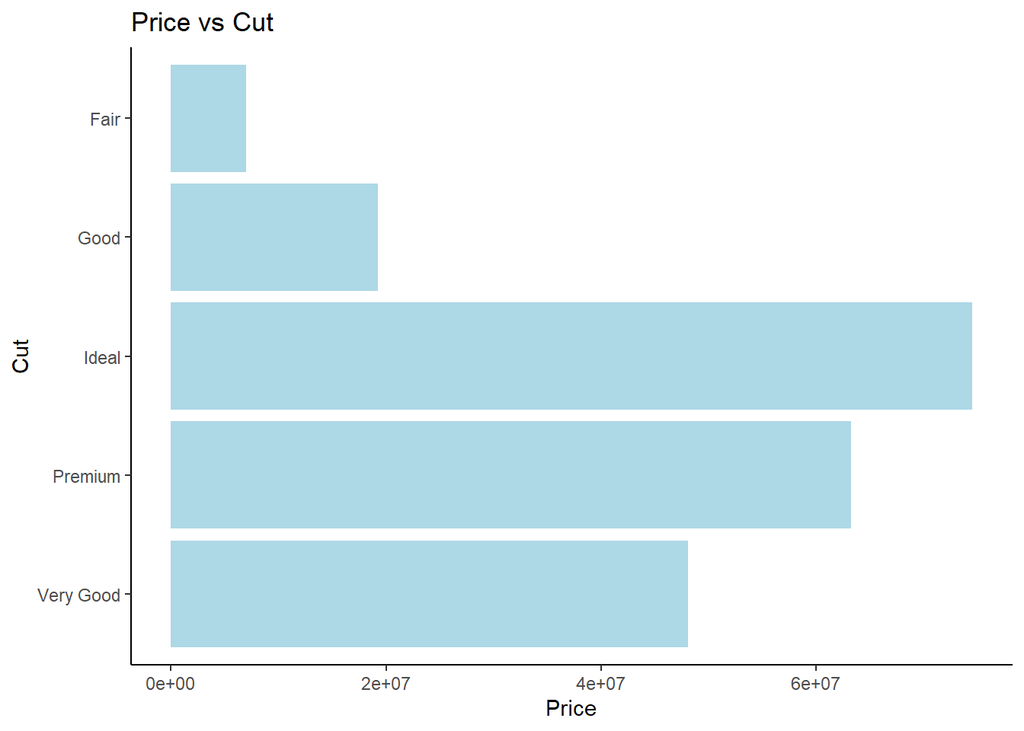

```r
# Make the same plot but with the order of cut from lowest to highest
ggplot(diamonds, aes(x = fct_rev(cut), y = price)) +
    geom_col(fill = "light blue") +
    coord_flip() +
    labs(title = "Price vs Cut", y = "Price", x = "Cut")
```

## Conclusion

In this notebook we want through a couple of the main packages and functions used in the tidyverse package. However, there are still other packages we did not look at in the tidyverse, such as [tidyr](https://tidyr.tidyverse.org/), and other packages that work well with the tidyverse. Some of these packages are [lubridate](https://lubridate.tidyverse.org/) for working with dates and times, and [tidymodels](https://www.tidymodels.org/) for modeling data.